# Syntax Tugas Pertemuan 67

Muhamad Farras Surya Dio Putra

2023-10-02

## Packages

```r
library(ggplot2)
library(tsibble)
library(tseries)
library(MASS)
library(forecast)
library(TSA)
library(TTR)
library(aTSA)
library(graphics)
```

## Input Data

```r
library(rio)
databaru <- import("https://raw.githubusercontent.com/farrasdp/mpdw/main/Pertemuan%205/dataset%20tugas.csv")
databaru
```

```
##     Periode Returning.Visits
## 1         1              277
## 2         2              462
## 3         3              534
## 4         4              437
## 5         5              261
## 6         6              398
## 7         7              550
## 8         8              597
## 9         9              585
## 10       10              538
## 11       11              477
## 12       12              309
## 13       13              386
## 14       14              588
```

[output cut: 351 more lines]

## Data Time Series

Membuat data time series dari data awal

```r
databaru.ts <- ts(databaru$Returning.Visits)
```

Data kemudian dibagi menjadi data latih dan data uji.

```r
databaru.train <- databaru.ts[1:285]
databaru.test <- databaru.ts[286:365]
databaru.train<- ts(databaru.train)
databaru.test <- ts(databaru.test)
```

## Eksplorasi Data

Sebelum masuk dalam tahap pemodelan, dilakukan eksplorasi data dengan plot deret waktu untuk melihat pola data.

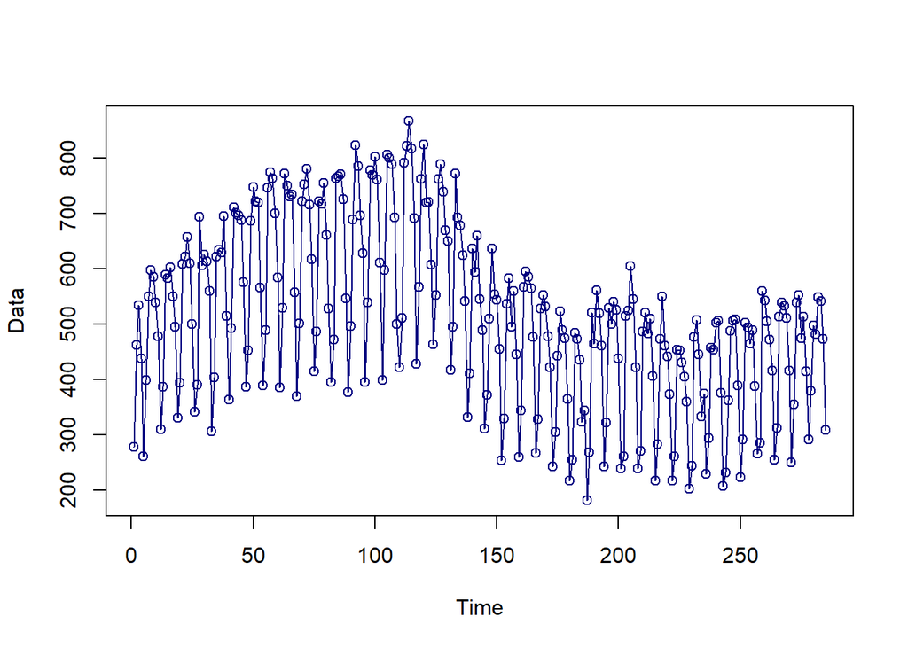

```r
#--PLOT TIME SERIES--#
plot(databaru.train,
     col = "navyblue",
     lwd = 1,
     type = "o",
     xlab = "Time",
     ylab = "Data")
```

Berdasarkan plot data deret waktu di atas, terlihat data cenderung **tidak stasioner dalam rataan** karena data tersebut tidak menyebar/bergerak di sekitar nilai tengahnya dan **stasioner dalam ragam** karena memiliki lebar pita yang cenderung sama. Selain dengan plot data deret waktu, akan dilakukan pengecekan stasioneritas data dengan plot ACF dan uji ADF.

### Plot ACF

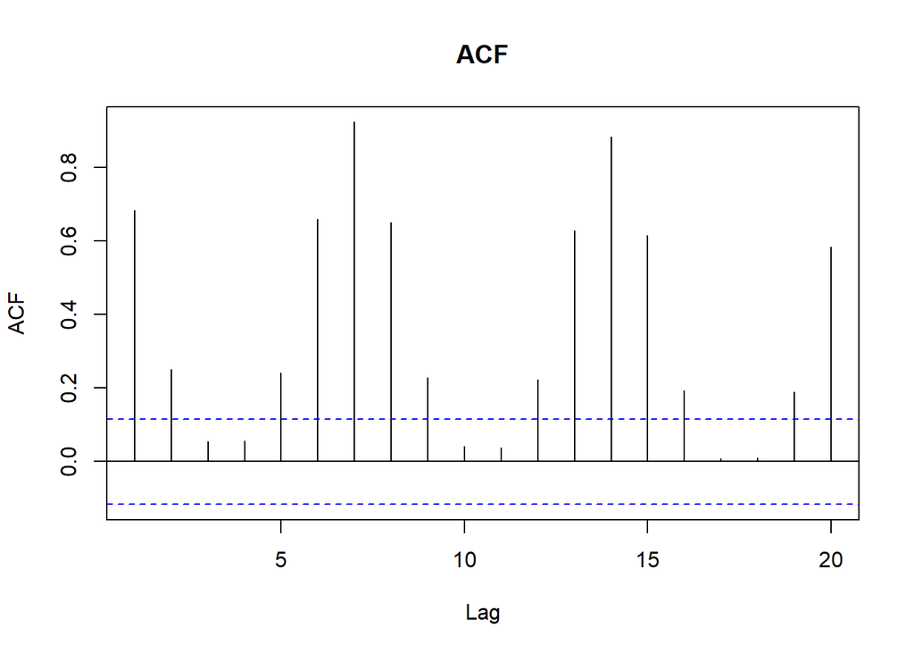

```r
acf(databaru.train, main="ACF", lag.max=20)
```

Berdasarkan plot ACF, terlihat bahwa plot ACF pada data tersebut cenderung *tails off slowly* maka data tersebut terindikasi tidak stasioner

### ADF

```r
tseries::adf.test(databaru.train, k = 6)
```

```
##
##  Augmented Dickey-Fuller Test
##
## data:  databaru.train
## Dickey-Fuller = -2.7685, Lag order = 6, p-value = 0.2523
## alternative hypothesis: stationary
```

$H_0$ : Data tidak stasioner dalam rataan

$H_1$ : Data stasioner dalam rataan

Berdasarkan uji ADF tersebut, didapat *p-value* sebesar 0.2523 yang lebih besar dari taraf nyata 5% sehingga tak tolak $H_0$ dan menandakan bahwa data tidak stasioner dalam rataan. Hal ini sesuai dengan hasil eksplorasi menggunakan plot time series dan plot ACF, sehingga ketidakstasioneran model kedepannya harus ditangani

### Boxcox

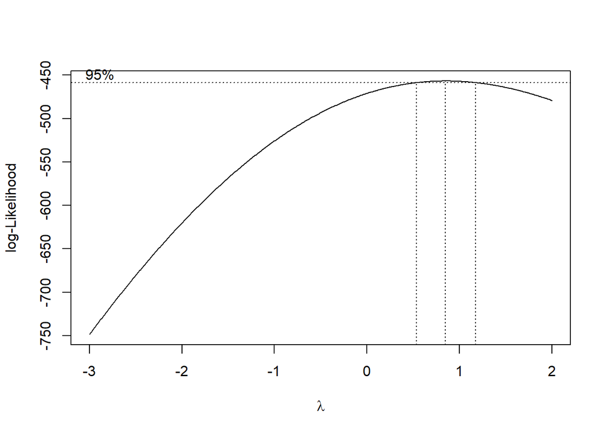

```r
index <- seq(1:285) #sebanyak row data
bc = boxcox(databaru.train~index, lambda = seq(-3,2,by=0.01))
```

```r
#Nilai Rounded Lambda
lambda <- bc$x[which.max(bc$y)]
lambda
```

```
## [1] 0.85
```

```r
#SK
bc$x[bc$y > max(bc$y) - 1/2 * qchisq(.95,1)]
```

```
##  [1] 0.54 0.55 0.56 0.57 0.58 0.59 0.60 0.61 0.62 0.63 0.64 0.65 0.66 0.67 0.68
## [16] 0.69 0.70 0.71 0.72 0.73 0.74 0.75 0.76 0.77 0.78 0.79 0.80 0.81 0.82 0.83
## [31] 0.84 0.85 0.86 0.87 0.88 0.89 0.90 0.91 0.92 0.93 0.94 0.95 0.96 0.97 0.98
## [46] 0.99 1.00 1.01 1.02 1.03 1.04 1.05 1.06 1.07 1.08 1.09 1.10 1.11 1.12 1.13
## [61] 1.14 1.15 1.16 1.17
```

Plot Boxcox menunjukkan nilai *rounded value* ($\lambda$) optimum sebesar **0.85** dan pada selang kepercayaan 95% nilai memiliki batas bawah **0.54** dan batas atas **1.17**. Selang tersebut memuat nilai satu sehingga dapat dikatakan bahwa data bangkitan stasioner dalam ragam.

## Penanganan Ketidakstasioneran Data

Plot Difference

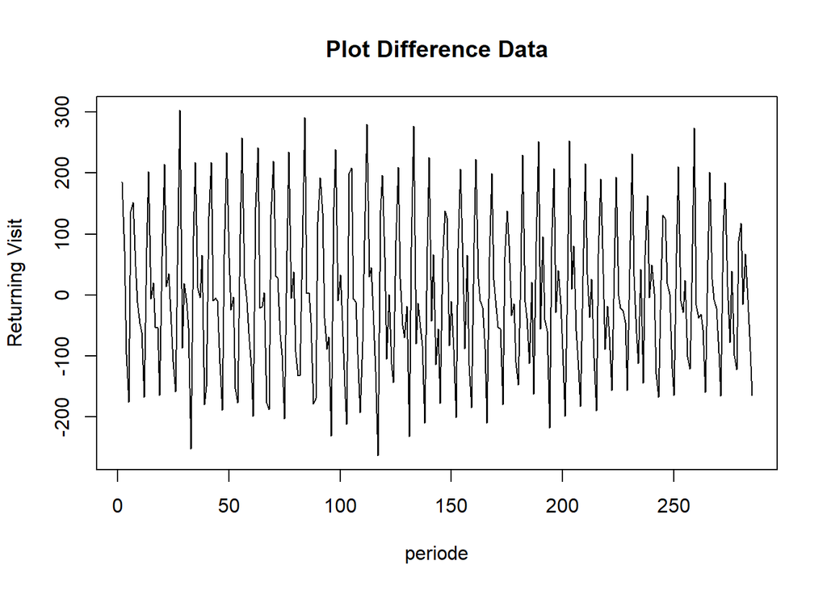

```r
databaru.diff<-diff(databaru.train,differences = 1)
plot.ts(databaru.diff, lty=1, xlab="periode", ylab="Returning Visit", main="Plot Difference Data")
```

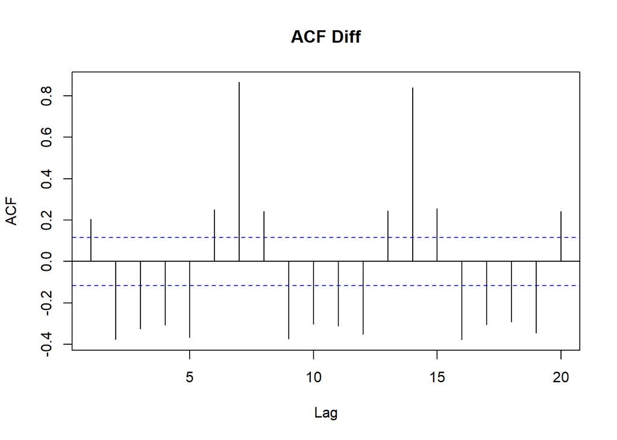

```r
acf(databaru.diff, main="ACF Diff", lag.max=20)
```

### ADF

```r
tseries::adf.test(databaru.diff)
```

```
##
##  Augmented Dickey-Fuller Test
##
## data:  databaru.diff
## Dickey-Fuller = -11.923, Lag order = 6, p-value = 0.01
## alternative hypothesis: stationary
```

$H_0$ : Data tidak stasioner dalam rataan

$H_1$ : Data stasioner dalam rataan

Berdasarkan uji ADF tersebut, didapat *p-value* sebesar 0.01 yang lebih kecil dari taraf nyata 5% sehingga tolak $H_0$ atau data stasioner dalam rataan. Hal ini sesuai dengan hasil eksplorasi menggunakan plot time series dan plot ACF, sehingga dalam hal ini ketidakstasioneran data sudah berhasil ditangani dan dapat dilanjutkan ke pemodelan

## Identifikasi Model

### Plot ACF

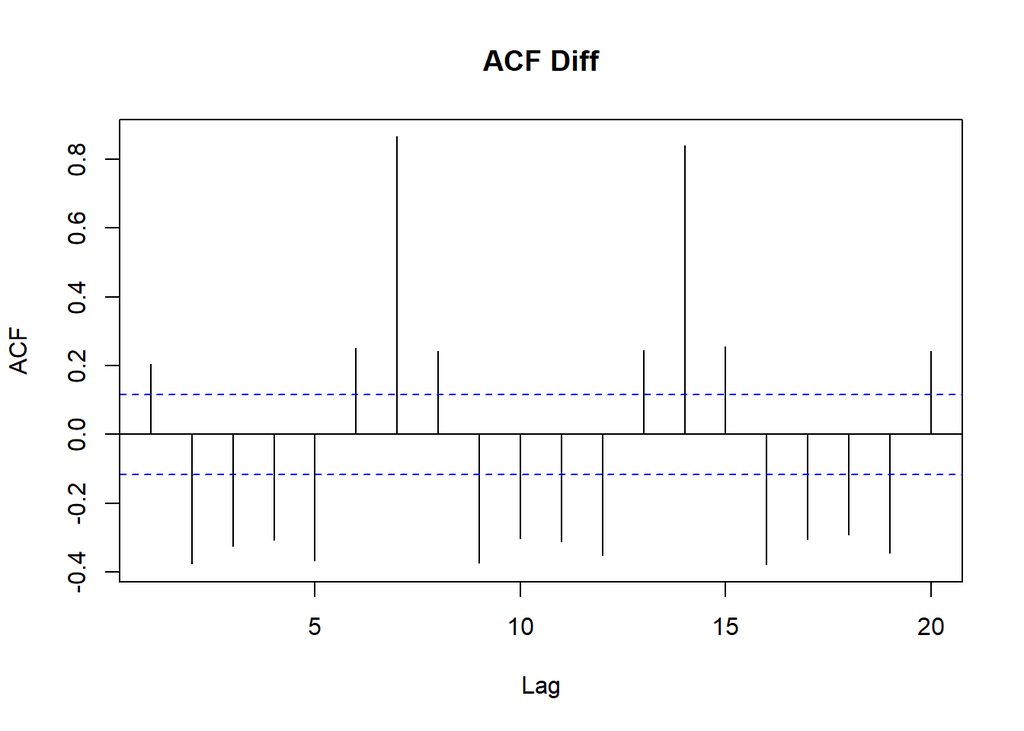

```r
acf(databaru.diff, main="ACF Diff", lag.max=20)
```

### Plot PACF

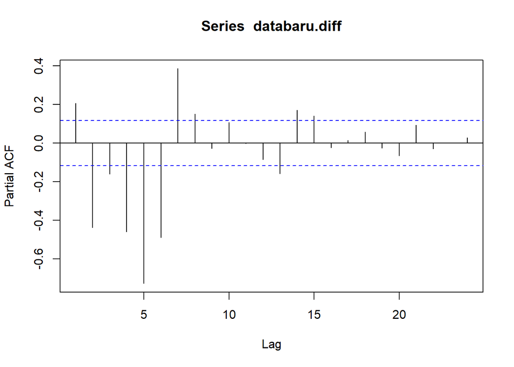

```r
pacf(databaru.diff)
```

### Plot EACF

```r
eacf(databaru.diff)
```

```
## AR/MA
##   0 1 2 3 4 5 6 7 8 9 10 11 12 13
## 0 x x x x x x x x x x x  x  x  x
## 1 x x o o x x x x x o o  x  x  x
## 2 x x x o x o x o x x o  x  o  x
## 3 x x o o x o x o x o o  x  o  x
## 4 x x x o o x x x x o o  o  x  x
## 5 x x x o x x x x x o x  x  x  x
## 6 x x x x o o x o o x o  x  o  o
## 7 x x x x o o x o o o o  o  o  o
```

Identifikasi model menggunakan plot EACF dilakukan dengan melihat ujung segitiga pada pola segitiga nol. Dalam hal ini model tentatif yang terbentuk adalah ARIMA(1,1,2), ARIMA(3,1,2).

## Pendugaan Parameter Model Tentatif

### ARIMA(0,1,1)

```r
model1.da=Arima(databaru.diff, order=c(0,1,1),method="ML")
summary(model1.da)
```

```
## Series: databaru.diff
## ARIMA(0,1,1)
##
## Coefficients:
##           ma1
##       -1.0000
## s.e.   0.0091
##
## sigma^2 = 15598:  log likelihood = -1770.05
## AIC=3544.1   AICc=3544.14   BIC=3551.39
##
## Training set error measures:
##                     ME     RMSE      MAE      MPE     MAPE      MASE      ACF1
## Training set -5.247079 124.4502 99.53539 103.4912 107.8633 0.7789534 0.2104685
```

```r
lmtest::coeftest(model1.da)
```

```
##
## z test of coefficients:
##
##       Estimate Std. Error z value  Pr(>|z|)
## ma1 -0.9999997  0.0091415 -109.39 < 2.2e-16 ***
## ---
## Signif. codes:  0 '***' 0.001 '**' 0.01 '*' 0.05 '.' 0.1 ' ' 1
```

AIC=3544.1 Peubah Signifikan

### ARIMA(1,1,0)

```r
model2.da=Arima(databaru.diff, order=c(1,1,0),method="ML")
summary(model2.da)
```

```
## Series: databaru.diff
## ARIMA(1,1,0)
##
## Coefficients:
##           ar1
##       -0.1300
## s.e.   0.0589
##
## sigma^2 = 24159:  log likelihood = -1829.14
## AIC=3662.29   AICc=3662.33   BIC=3669.58
##
## Training set error measures:
##                     ME     RMSE      MAE      MPE     MAPE     MASE        ACF1
## Training set -1.344174 154.8833 129.4142 234.5052 431.6235 1.012782 -0.05494112
```

```r
lmtest::coeftest(model2.da)
```

```
##
## z test of coefficients:
##
##      Estimate Std. Error z value Pr(>|z|)
## ar1 -0.129997   0.058932 -2.2059  0.02739 *
## ---
## Signif. codes:  0 '***' 0.001 '**' 0.01 '*' 0.05 '.' 0.1 ' ' 1
```

AIC=3662.29 Peubah Signifikan

### ARIMA(1,1,2)

```r
model3.da=Arima(databaru.diff, order=c(1,1,2),method="ML")
summary(model3.da)
```

```
## Series: databaru.diff
## ARIMA(1,1,2)
##
## Coefficients:
##           ar1      ma1      ma2
##       -0.2516  -0.3705  -0.6295
## s.e.   0.1138   0.0887   0.0884
##
## sigma^2 = 13661:  log likelihood = -1750.13
## AIC=3508.27   AICc=3508.41   BIC=3522.85
##
## Training set error measures:
##                     ME     RMSE      MAE      MPE     MAPE      MASE
## Training set -4.731364 116.0559 98.48969 139.3004 193.6726 0.7707699
##                     ACF1
## Training set -0.03714972
```

```r
lmtest::coeftest(model3.da)
```

```
##
## z test of coefficients:
##
##      Estimate Std. Error z value  Pr(>|z|)
## ar1 -0.251634   0.113805 -2.2111   0.02703 *
## ma1 -0.370541   0.088666 -4.1791 2.927e-05 ***
## ma2 -0.629458   0.088385 -7.1217 1.066e-12 ***
## ---
## Signif. codes:  0 '***' 0.001 '**' 0.01 '*' 0.05 '.' 0.1 ' ' 1
```

AIC=3508.27 Peubah Signifikan

### ARIMA(3,1,2)

```r
model4.da=Arima(databaru.diff, order=c(3,1,2),method="ML")
summary(model4.da)
```

```
## Series: databaru.diff
## ARIMA(3,1,2)
##
## Coefficients:
##          ar1      ar2      ar3      ma1     ma2
##       0.6571  -0.4773  -0.1915  -1.8642  0.8688
## s.e.  0.0616   0.0647   0.0607   0.0281  0.0284
##
## sigma^2 = 7783:  log likelihood = -1671.5
## AIC=3355   AICc=3355.3   BIC=3376.87
##
## Training set error measures:
##                     ME    RMSE      MAE      MPE     MAPE      MASE       ACF1
## Training set -5.713229 87.2868 70.02679 102.5674 276.4875 0.5480222 -0.0949242
```

```r
lmtest::coeftest(model4.da)
```

```
##
## z test of coefficients:
##
##      Estimate Std. Error  z value  Pr(>|z|)
## ar1  0.657144   0.061562  10.6746 < 2.2e-16 ***
## ar2 -0.477252   0.064690  -7.3775 1.612e-13 ***
## ar3 -0.191516   0.060714  -3.1544  0.001608 **
## ma1 -1.864194   0.028137 -66.2539 < 2.2e-16 ***
## ma2  0.868805   0.028446  30.5427 < 2.2e-16 ***
## ---
## Signif. codes:  0 '***' 0.001 '**' 0.01 '*' 0.05 '.' 0.1 ' ' 1
```

AIC=3355 Peubah Signifikan

## Analisis Sisaan

Model terbaik hasil identifikasi kemudian dicek asumsi sisaannya. Sisaan model ARIMA harus memenuhi asumsi normalitas, kebebasan sisaan, dan kehomogenan ragam. Diagnostik model dilakukan secara eksplorasi dan uji formal.

#### Eksplorasi Sisaan ARIMA (3,1,2)

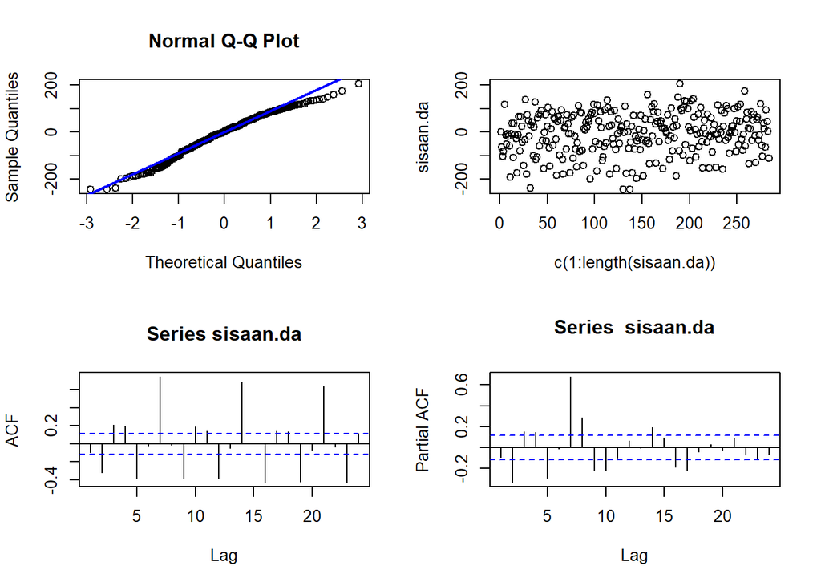

```r
#Eksplorasi
sisaan.da <- model4.da$residuals
par(mfrow=c(2,2))
qqnorm(sisaan.da)
qqline(sisaan.da, col = "blue", lwd = 2)
plot(c(1:length(sisaan.da)),sisaan.da)
acf(sisaan.da)
pacf(sisaan.da)
```

```r
par(mfrow = c(1,1))
```

## Uji Formal

### 1. Sisaan Menyebar Normal

```r
ks.test(sisaan.da,"pnorm")  #tak tolak H0 > sisaan menyebar normal
```

```
##
##  Asymptotic one-sample Kolmogorov-Smirnov test
##
## data:  sisaan.da
## D = 0.49416, p-value < 2.2e-16
## alternative hypothesis: two-sided
```

Selain dengan eksplorasi, asumsi tersebut dapat diuji menggunakan uji formal. Pada tahapan ini uji formal yang digunakan untuk normalitas adalah uji Kolmogorov-Smirnov (KS). Hipotesis pada uji KS adalah sebagai berikut.

$H_0$ : Sisaan menyebar normal

$H_1$ : Sisaan tidak menyebar normal

Berdasarkan uji KS tersebut, didapat *p-value* sebesar < 2.2e-16 yang kurang dari taraf nyata 5% sehingga tolak $H_0$ dan menandakan bahwa sisaan tidak menyebar normal. Hal ini sesuai dengan hasil eksplorasi menggunakan plot kuantil-kuantil normal.

### 2. Sisaan Saling bebas/tidak ada autokorelasi

```r
Box.test(sisaan.da, type = "Ljung")  #tak tolak H0 > sisaan saling bebas
```

```
##
##  Box-Ljung test
##
## data:  sisaan.da
## X-squared = 2.5861, df = 1, p-value = 0.1078
```

Selanjutnya akan dilakukan uji formal untuk kebebasan sisaan menggunakan uji Ljung-Box. Hipotesis yang digunakan adalah sebagai berikut.

$H_0$ : Sisaan saling bebas

$H_1$ : Sisaan tidak tidak saling bebas

```r
Box.test((sisaan.da)^2, type = "Ljung")  #tak tolak H0 > sisaan homogen
```

```
##
##  Box-Ljung test
##
## data:  (sisaan.da)^2
## X-squared = 12.399, df = 1, p-value = 0.0004295
```

Hipotesis yang digunakan untuk uji kehomogenan ragam adalah sebagai berikut.

$H_0$ : Ragam sisaan homogen

$H_1$ : Ragam sisaan tidak homogen

### 4. Nilai tengah sisaan sama dengan nol

```r
t.test(sisaan.da, mu = 0, conf.level = 0.95)  #tak tolak h0 > nilai tengah sisaan sama dengan 0
```

```
##
##  One Sample t-test
##
## data:  sisaan.da
## t = -1.1035, df = 283, p-value = 0.2708
## alternative hypothesis: true mean is not equal to 0
## 95 percent confidence interval:
##  -15.904595   4.478138
## sample estimates:
## mean of x
## -5.713229
```

Terakhir, dengan uji-t, akan dicek apakah nilai tengah sisaan sama dengan nol. Hipotesis yang diujikan sebagai berikut.

$H_0$ : nilai tengah sisaan sama dengan 0

$H_1$ : nilai tengah sisaan tidak sama dengan 0

Berdasarkan uji-ttersebut, didapat *p-value* sebesar 0.2708 yang lebih besar dari taraf nyata 5% sehingga tak tolak $H_0$ dan menandakan bahwa nilai tengah sisaan sama dengan nol.

## Overfitting

Tahapan selanjutnya adalah *overfitting* dilakukan dengan **menaikkan orde AR(p) dan MA(q)** dari model ARIMA(3,1,2) untuk melihat apakah terdapat model lain yang lebih baik dari model saat ini. Kandidat model *overfitting* adalah ARIMA(4,1,2) dan ARIMA(3,1,3).

```r
model1a.ma2=Arima(databaru.ts, order=c(4,1,2),method="ML")
summary(model1a.ma2)
```

```
## Series: databaru.ts
## ARIMA(4,1,2)
##
## Coefficients:
##          ar1      ar2     ar3      ar4      ma1     ma2
##       0.7468  -1.0723  0.3679  -0.6934  -1.1793  0.8795
## s.e.  0.0415   0.0526  0.0523   0.0406   0.0395  0.0345
##
## sigma^2 = 3675:  log likelihood = -2010.97
## AIC=4035.94   AICc=4036.25   BIC=4063.22
##
## Training set error measures:
##                      ME    RMSE      MAE       MPE   MAPE      MASE       ACF1
## Training set -0.8965994 60.0409 46.87562 -2.027058 11.107 0.4826523 -0.1467837
```

```r
lmtest::coeftest(model1a.ma2)
```

```
##
## z test of coefficients:
##
##      Estimate Std. Error  z value  Pr(>|z|)
## ar1  0.746783   0.041533  17.9805 < 2.2e-16 ***
## ar2 -1.072288   0.052610 -20.3817 < 2.2e-16 ***
## ar3  0.367864   0.052301   7.0336 2.012e-12 ***
## ar4 -0.693353   0.040615 -17.0715 < 2.2e-16 ***
## ma1 -1.179344   0.039461 -29.8866 < 2.2e-16 ***
## ma2  0.879519   0.034548  25.4578 < 2.2e-16 ***
## ---
## Signif. codes:  0 '***' 0.001 '**' 0.01 '*' 0.05 '.' 0.1 ' ' 1
```

```r
model1b.ma2=Arima(databaru.ts, order=c(3,1,3),method="ML")
summary(model1b.ma2) #327.24
```

```
## Series: databaru.ts
## ARIMA(3,1,3)
##
## Coefficients:
##          ar1      ar2      ar3      ma1      ma2     ma3
##       0.4726  -0.0673  -0.6278  -0.7223  -0.4062  0.6663
## s.e.  0.1206   0.1423   0.1144   0.1059   0.1490  0.0826
##
## sigma^2 = 6015:  log likelihood = -2099.1
## AIC=4212.2   AICc=4212.52   BIC=4239.48
##
## Training set error measures:
##                      ME    RMSE      MAE       MPE     MAPE      MASE
## Training set -0.5876643 76.8069 62.90119 -2.997714 14.64796 0.6476588
##                    ACF1
## Training set -0.1228121
```

```r
lmtest::coeftest(model1b.ma2)
```

```
##
## z test of coefficients:
##
##      Estimate Std. Error z value  Pr(>|z|)
## ar1  0.472561   0.120622  3.9177 8.939e-05 ***
## ar2 -0.067260   0.142311 -0.4726  0.636480
## ar3 -0.627790   0.114352 -5.4900 4.020e-08 ***
## ma1 -0.722255   0.105864 -6.8225 8.949e-12 ***
## ma2 -0.406245   0.148978 -2.7269  0.006394 **
## ma3  0.666317   0.082595  8.0673 7.189e-16 ***
## ---
## Signif. codes:  0 '***' 0.001 '**' 0.01 '*' 0.05 '.' 0.1 ' ' 1
```

```r
#model yang dipilih adalah model awal, yaitu ARIMA(1,1,1)
```

Berdasarkan kedua model hasil *overfitting* di atas, model ARIMA(4,1,2) dan ARIMA(3,1,3) memiliki AIC yang lebih besar dibandingkan dengan model ARIMA(3,1,2) dan parameter model ARIMA(3,1,3) tidak seluruhnya signifikan. Oleh karena itu, model ARIMA(3,1,2) akan tetap digunakan untuk melakukan peramalan.

## Peramalan

Peramalan dilakukan menggunakan fungsi `forecast()` . Contoh peramalan berikut ini dilakukan untuk 80 tahun ke depan.

```r
#---FORECAST---#
ramalan.da <- forecast::forecast(model4.da, h = 80)
ramalan.da
```

```
##     Point Forecast       Lo 80     Hi 80      Lo 95    Hi 95
## 286    21.84964707  -91.213595 134.91289 -151.06566 194.7650
## 287   107.11711575   -8.344205 222.57844  -69.46574 283.7000
## 288    92.55273185  -41.863714 226.96918 -113.01948 298.1249
## 289     6.50310257 -138.800832 151.80704 -215.72009 228.7263
## 290   -59.42304342 -204.735624  85.88954 -281.65946 162.8134
## 291   -58.88931115 -209.897234  92.11861 -289.83600 172.0574
## 292   -10.59531737 -166.148861 144.95823 -248.49393 227.3033
## 293    33.51194425 -122.126589 189.15048 -204.51665 271.5405
## 294    39.34611996 -117.809318 196.50156 -201.00238 279.6946
## 295    12.88066508 -146.006815 171.76814 -230.11677 255.8781
## 296   -15.74254873 -174.723223 143.23813 -258.88251 227.3974
## 297   -23.03875283 -182.493173 136.41567 -266.90324 220.8257
## 298    -9.10436491 -169.326998 151.11827 -254.14374 235.9350
## 299     9.01645504 -151.318481 169.35139 -236.19467 254.2276
```

[output cut: 66 more lines]

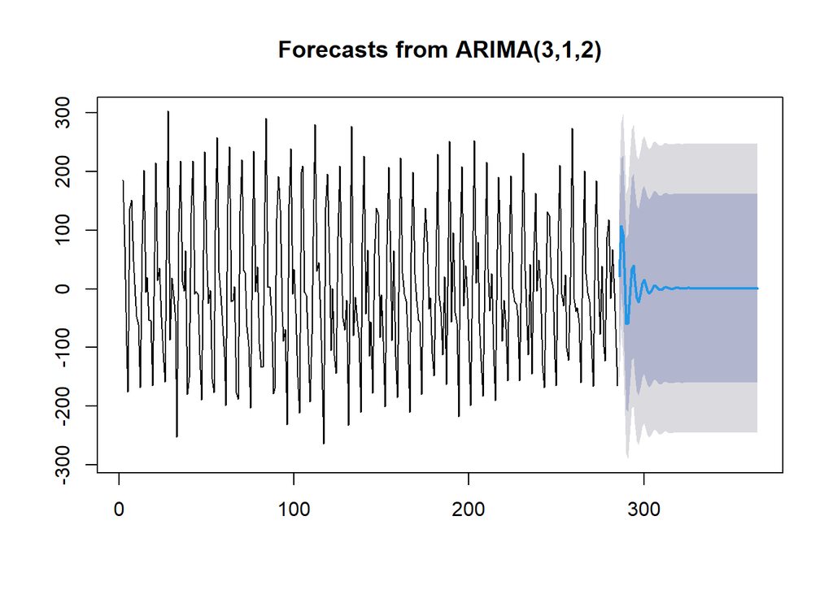

```r
data.ramalan.da <- ramalan.da$mean
plot(ramalan.da)
```

Berdasarkan hasil plot ramalan di atas, dapat dilihat bahwa ramalan ARIMA(3,1,2) cenderung stabil hingga akhir periode, tetapi terdapat tren pada awal forecast . Selanjutnya, dapat dicari nilai akurasi antara hasil ramalan dengan data uji sebagai berikut.

## Diff invers

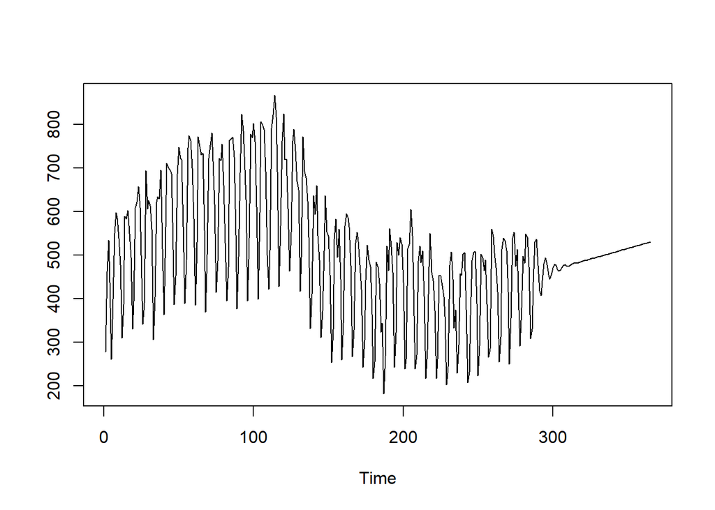

```r
pt_1 <- databaru.train[285] #nilai akhir data
hasil.forc.Diff <- data.ramalan.da
hasil <- diffinv(hasil.forc.Diff, differences = 1) + pt_1
#has.1 sama hasilnta dengan: cumsum(c(pt_1,hasil.forc.Diff))

ts.plot(databaru.train,hasil)
```

## Accuracy

```r
perbandingan.da<-matrix(data=c(head(databaru.train, n=30), hasil[-1]),
                     nrow = 30, ncol = 2)
colnames(perbandingan.da)<-c("Aktual","Hasil Forecast")
perbandingan.da
```

```
##       Aktual Hasil Forecast
##  [1,]    277       329.8496
##  [2,]    462       436.9668
##  [3,]    534       529.5195
##  [4,]    437       536.0226
##  [5,]    261       476.5996
##  [6,]    398       417.7102
##  [7,]    550       407.1149
##  [8,]    597       440.6269
##  [9,]    585       479.9730
## [10,]    538       492.8537
## [11,]    477       477.1111
## [12,]    309       454.0724
## [13,]    386       444.9680
## [14,]    588       453.9844
```

[output cut: 16 more lines]

```r
accuracy(ts(hasil[-1]), head(databaru.train, n=30))
```

```
##                ME     RMSE      MAE       MPE     MAPE      ACF1 Theil's U
## Test set 34.44462 117.6369 102.3191 0.9596161 21.75815 0.4618341 0.8064434
```

```r
accuracy(ts(hasil[-1]), head(databaru.test, n=30))
```

```
##                ME     RMSE      MAE      MPE     MAPE      ACF1 Theil's U
## Test set 43.41129 112.3657 96.43213 3.682269 19.72782 0.4204028 0.8032573
```